# edgeR with different models

Nisha paudel

2023-09-13

## Experiments with combinations of multiple factors

Instructions for the code are from https://f1000research.com/articles/5-1438 and edgeR bioconductor manual and chapter 3.3 page 36 of edgeR manual https://bioconductor.org/packages/release/bioc/vignettes/edgeR/inst/doc/edgeRUsersGuide.pdf

Based on edgeR quasilikelihood pipeline, NB model with F tests -because of strict error control rate than traditional edgeR and DESeq2 -limma also offer excellent error control and are recommended for large datasets due to its speed

The data is from a paper Generation of a microglial developmental index in mice and in humans reveals a sex difference in maturation and immune reactivity Published in Glia in 2017.

Here is analysis for P60 sal, E18, P4, P14 for both male and female. We are using design <- model.matrix(~ 0 + Group), where group is interation Sex * Age, this design is easy to implement and recommended by authors is equivalent to design <- model.matrix(~ 0 + Sex + Sex:Age, data=targets)/(~ 0+ Sex +Sex:Age) **this is called Nested factor Design** page 34

## load libraries and data

```r
library(edgeR)
library(limma)
count_data1 <- read.csv('/Users/nishapaudel/Documents/CASP/Data/Counts.csv', sep =',', header=T, row.names = 1)
sampleinfo <- read.csv("/Users/nishapaudel/Documents/CASP/Data/NEW_design.txt", sep = ',', header = TRUE, row.names = 1, stringsAsFactors = TRUE)
sampleinfo
```

```
##           Sex   Age Treatment
## F_E18_1     F   E18         N
## M_E18_1     M   E18         N
## F_E18_3     F   E18         N
## M_E18_4     M   E18         N
## F_P14_1     F   P14         N
## F_P14_2     F   P14         N
## F_P14_3     F   P14         N
## F_P14_4     F   P14         N
## F_P14_5     F   P14         N
## F_P14_6     F   P14         N
## F_P14_7     F   P14         N
## F_P14_8     F   P14         N
## F_P14_9     F   P14         N
## F_P14_10    F   P14         N
## M_P4_1      M    P4         N
## F_P4_2      F    P4         N
## F_P4_3      F    P4         N
## F_P4_4      F    P4         N
## F_P60_S_1   F P60_S         S
## F_P60_S_2   F P60_S         S
## F_P60_S_3   F P60_S         S
## F_P60_S_4   F P60_S         S
## F_P60_S_5   F P60_S         S
## M_P60_S_5   M P60_S         S
## F_P60_S_7   F P60_S         S
## F_E18_2     F   E18         N
## M_E18_2     M   E18         N
## M_E18_3     M   E18         N
## M_P14_1     M   P14         N
## M_P14_2     M   P14         N
## M_P14_3     M   P14         N
## M_P14_4     M   P14         N
## M_P14_5     M   P14         N
## M_P14_6     M   P14         N
## M_P14_7     M   P14         N
## M_P14_8     M   P14         N
## M_P14_9     M   P14         N
## M_P14_10    M   P14         N
## F_P4_1      F    P4         N
## M_P4_2      M    P4         N
## M_P4_3      M    P4         N
## M_P4_4      M    P4         N
## M_P60_S_1   M P60_S         S
## M_P60_S_2   M P60_S         S
## M_P60_S_3   M P60_S         S
## M_P60_S_4   M P60_S         S
## F_P60_S_6   F P60_S         S
```

```r
dim(count_data1)
```

```
## [1] 21987    47
```

## Grouping for interation

```r
group <- factor(paste0(sampleinfo$Sex, ".", sampleinfo$Age))
y <- DGEList(count_data1, group=group)
```

## Filter

```r
keep <- filterByExpr(y)
summary(keep)
```

```
##    Mode   FALSE    TRUE
## logical    8619   13368
```

## Normalize

```r
y <- normLibSizes(y) # Default normalization is TMM
y$samples
```

```
##             group lib.size norm.factors
## F_E18_1     F.E18  2280249    1.1953874
## M_E18_1     M.E18  1642408    1.2110513
## F_E18_3     F.E18  1911439    1.2089351
## M_E18_4     M.E18  1350713    0.7915012
## F_P14_1     F.P14  1732352    0.9095468
## F_P14_2     F.P14  2485650    0.9443663
## F_P14_3     F.P14  2229777    1.0039265
## F_P14_4     F.P14  2932799    0.9357666
## F_P14_5     F.P14  1921692    1.0204049
## F_P14_6     F.P14   860919    0.9943144
## F_P14_7     F.P14   891773    0.9909896
## F_P14_8     F.P14  3441194    0.8817322
## F_P14_9     F.P14  2975816    0.8808826
## F_P14_10    F.P14  2285897    0.9045013
## M_P4_1       M.P4  1849794    1.1708858
## F_P4_2       F.P4  2378107    1.1010462
## F_P4_3       F.P4  2737281    1.1202893
## F_P4_4       F.P4  1960248    1.1026138
## F_P60_S_1 F.P60_S  3118656    0.9040744
## F_P60_S_2 F.P60_S   958471    0.9337708
## F_P60_S_3 F.P60_S  2539386    0.9348238
## F_P60_S_4 F.P60_S   850724    0.9509033
## F_P60_S_5 F.P60_S   865073    0.9551727
## M_P60_S_5 M.P60_S  2336264    0.9634292
## F_P60_S_7 F.P60_S  1061145    0.9801916
## F_E18_2     F.E18  2289659    1.1884664
## M_E18_2     M.E18  2626224    1.2113179
## M_E18_3     M.E18  2707992    1.1352097
## M_P14_1     M.P14  2411309    0.8484100
## M_P14_2     M.P14  2064459    0.9103570
## M_P14_3     M.P14  2105607    0.9321873
## M_P14_4     M.P14  1024998    1.0380263
## M_P14_5     M.P14   957797    1.0449691
## M_P14_6     M.P14   959757    1.0766574
## M_P14_7     M.P14   923115    1.0474464
## M_P14_8     M.P14  1156933    0.9352680
## M_P14_9     M.P14  1087470    0.9155247
## M_P14_10    M.P14  2404167    0.9112265
## F_P4_1       F.P4  2516717    1.1317228
## M_P4_2       M.P4  2283997    1.1289809
## M_P4_3       M.P4  1889693    1.1337657
## M_P4_4       M.P4  3014192    1.0706423
## M_P60_S_1 M.P60_S  2343862    0.9394439
## M_P60_S_2 M.P60_S  3176221    0.9065772
## M_P60_S_3 M.P60_S  1947044    0.9584302
## M_P60_S_4 M.P60_S  2165314    0.9822206
## F_P60_S_6 F.P60_S   791292    0.8413522
```

## MDS

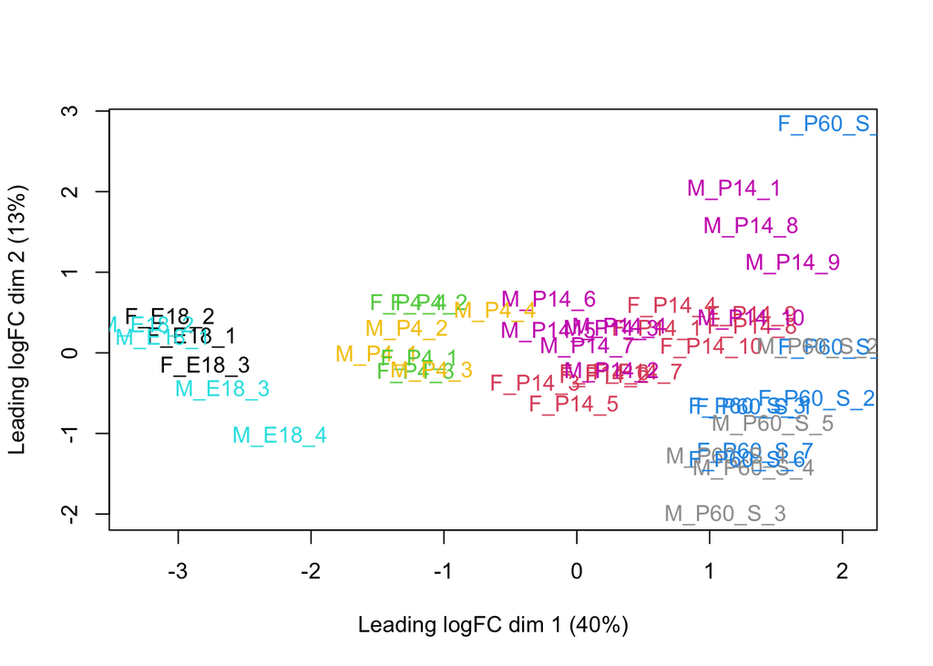

```r
plotMDS(y, col= as.numeric(group))
```

## Model Design

```r
design <- model.matrix(~ 0 + group)
colnames(design) <- levels(group)
design
```

```
##    F.E18 F.P14 F.P4 F.P60_S M.E18 M.P14 M.P4 M.P60_S
## 1      1     0    0       0     0     0    0       0
## 2      0     0    0       0     1     0    0       0
## 3      1     0    0       0     0     0    0       0
## 4      0     0    0       0     1     0    0       0
## 5      0     1    0       0     0     0    0       0
## 6      0     1    0       0     0     0    0       0
## 7      0     1    0       0     0     0    0       0
## 8      0     1    0       0     0     0    0       0
## 9      0     1    0       0     0     0    0       0
## 10     0     1    0       0     0     0    0       0
## 11     0     1    0       0     0     0    0       0
## 12     0     1    0       0     0     0    0       0
## 13     0     1    0       0     0     0    0       0
## 14     0     1    0       0     0     0    0       0
```

[output cut: 38 more lines]

## Dispersion estimation

```r
y <- estimateDisp(y, design, robust=TRUE)
y$common.dispersion
```

```
## [1] 0.09631879
```

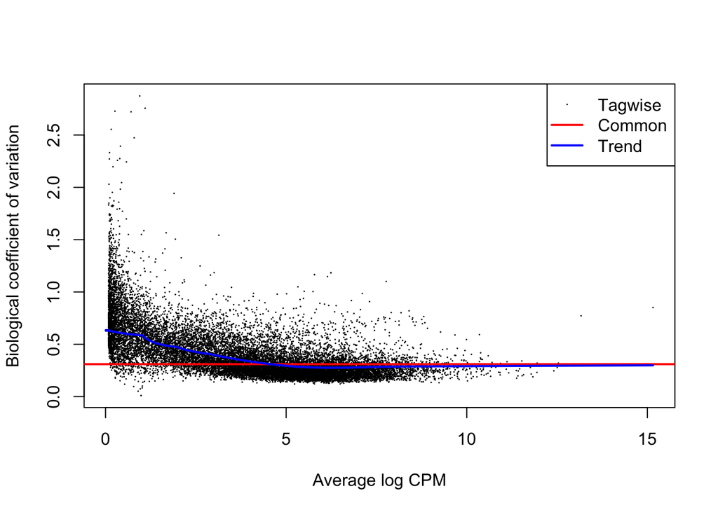

```r
plotBCV(y)
```

## Fitting to GLM

```r
fit <- glmQLFit(y, design, robust=TRUE)
head(fit$coefficients)
```

```
##                    F.E18      F.P14       F.P4    F.P60_S      M.E18      M.P14
## 0610005C13Rik -14.167416 -13.937249 -14.166358 -15.566101 -15.129526 -13.753026
## 0610007C21Rik  -9.648196  -9.338868  -9.527269  -8.924415  -8.621691  -9.341941
## 0610007L01Rik  -9.522360  -9.283014  -9.360247  -9.358750  -9.770905  -9.359759
## 0610007P08Rik -10.374252 -10.266193  -9.921632 -10.126582 -10.735231 -10.349891
## 0610007P14Rik -10.244402 -11.018497 -10.462233 -10.866033  -9.549325 -11.206860
## 0610007P22Rik -11.031225 -11.728945 -11.727864 -11.798380 -10.599622 -11.676066
##                     M.P4    M.P60_S
## 0610005C13Rik -15.621984 -13.883509
## 0610007C21Rik  -9.542872  -9.285582
## 0610007L01Rik  -9.394953  -9.340072
## 0610007P08Rik  -9.977303  -9.942166
## 0610007P14Rik -10.522014 -10.912334
## 0610007P22Rik -11.825076 -11.540025
```

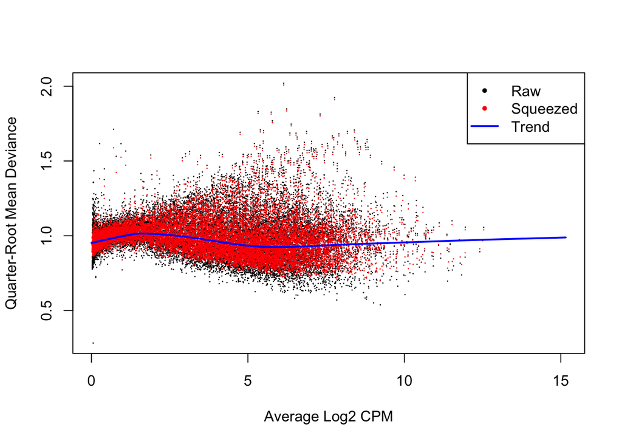

```r
plotQLDisp(fit)
```

## ANOVA-like testing -Sex wise DEGs at various age groups

```r
con <- makeContrasts(F18vsM18 = F.E18 - M.E18, FP4vsMP4  = F.P4 - M.P4,FP14vsMP14  = F.P14 - M.P14, FP60_SvsMP60_S = F.P60_S - M.P60_S, levels=design)
```

```r
anov <- glmQLFTest(fit, contrast=con)
topTags(anov)
```

```
## Coefficient:  LR test on 4 degrees of freedom
##         logFC.F18vsM18 logFC.FP4vsMP4 logFC.FP14vsMP14 logFC.FP60_SvsMP60_S
## Tsix         6.3632389     7.44149966        7.9191202            6.7886737
## Uty         -6.5584452    -8.16128445       -8.0365108           -5.9426346
## Xist         5.3277086     7.96539977        8.8706051            7.7192996
## Kdm5d       -8.8733415    -9.22978084       -6.3151502           -6.4699830
## Eif2s3y     -7.5796616    -7.73131070       -6.8099650           -4.3892238
## Ddx3y       -7.2352231    -8.34562818       -7.2020370           -4.9163838
## Kdm6a        1.3736434     0.80379095        0.6695341            0.8830669
## Akr7a5      -1.2132201    -0.03685179        0.4403368           -1.1273794
## Aldh2       -0.6496556    -0.14422372        0.7142284           -0.9793281
## Fam92b      -3.0960196     0.91637725        2.6178505           -0.8279014
##            logCPM          F       PValue          FDR
## Tsix     6.344254 290.019671 5.285778e-34 1.162184e-29
## Uty      4.655477 159.032198 9.957093e-28 1.094633e-23
## Xist    10.350543 145.370150 2.758204e-24 2.021488e-20
## Kdm5d    4.080505 105.483852 5.023058e-22 2.761049e-18
## Eif2s3y  5.478395  73.768984 2.224729e-18 9.783024e-15
## Ddx3y    7.106949  71.347403 7.627763e-18 2.795194e-14
## Kdm6a    6.731628  16.235222 1.359255e-08 4.269421e-05
## Akr7a5   3.802533   7.869093 5.284529e-05 1.452387e-01
## Aldh2    6.662513   7.490747 8.218922e-05 2.007883e-01
## Fam92b   1.744351   6.979710 1.509266e-04 3.265814e-01
```

```r
con <- makeContrasts(F18vsM18 = F.E18 - M.E18, levels=design)
qlf <- glmQLFTest(fit, contrast= con )
topTags(qlf)
```

```
## Coefficient:  1*F.E18 -1*M.E18
##             logFC    logCPM         F       PValue          FDR
## Tsix     6.363239  6.344254 172.68701 7.225011e-18 1.588563e-13
## Kdm5d   -8.873341  4.080505  68.12872 1.677917e-10 1.844618e-06
## Uty     -6.558445  4.655477  60.91574 3.397217e-10 2.489820e-06
## Xist     5.327709 10.350543  58.59107 1.532272e-09 8.422515e-06
## Eif2s3y -7.579662  5.478395  36.36398 3.658990e-07 1.609004e-03
## Ddx3y   -7.235223  7.106949  33.35120 9.250740e-07 3.389934e-03
## Kdm6a    1.373643  6.731628  23.10766 1.433921e-05 4.503947e-02
## Ech1    -1.616523  6.496132  20.27758 4.011572e-05 1.102530e-01
## Ssr2    -1.502873  7.018589  19.76282 4.861348e-05 1.187627e-01
## Rnf5    -1.149103  4.837515  19.18510 6.042890e-05 1.328650e-01
```

```r
summary(decideTests(qlf))
```

```
##        1*F.E18 -1*M.E18
## Down                  4
## NotSig            21980
## Up                    3
```

```r
table(p.adjust(qlf$table$PValue, method = "BH") < 0.05)
```

```
##
## FALSE  TRUE
## 21980     7
```

```r
dge<-topTags(qlf, n=Inf)
dge_edgR <-dge
sig <- subset(dge_edgR$table,FDR < 0.05)
dge_edgr_up_E18_sex <-rownames(subset(sig,logFC>0.4))
dge_edgr_down_E18_sex <-rownames(subset(sig,logFC<0.4))
```

```r
con <- makeContrasts( FP4vsMP4  = F.P4 - M.P4, levels=design)
qlf <- glmQLFTest(fit, contrast= con )
topTags(qlf)
```

```
## Coefficient:  1*F.P4 -1*M.P4
##                   logFC     logCPM         F       PValue          FDR
## Tsix           7.441500  6.3442540 237.55880 1.155047e-20 2.539601e-16
## Uty           -8.161284  4.6554772 126.67684 2.698656e-15 2.966767e-11
## Xist           7.965400 10.3505433 106.83224 3.384527e-13 2.480520e-09
## Kdm5d         -9.229781  4.0805050  98.69777 7.706964e-13 4.236325e-09
## Eif2s3y       -7.731311  5.4783946  61.04381 1.057743e-09 4.651321e-06
## Ddx3y         -8.345628  7.1069493  58.34607 2.199294e-09 8.059311e-06
## Snord15b       3.580498  0.8882164  12.04462 1.077181e-03 1.000000e+00
## Gm10549       -3.888953  0.4674286  10.91461 1.826451e-03 1.000000e+00
## 3830431G21Rik  3.718392  0.2379306  10.57517 2.258235e-03 1.000000e+00
## Lor            3.492483  0.1964115  10.81226 2.268083e-03 1.000000e+00
```

```r
summary(decideTests(qlf))
```

```
##        1*F.P4 -1*M.P4
## Down                4
## NotSig          21981
## Up                  2
```

```r
table(p.adjust(qlf$table$PValue, method = "BH") < 0.05)
```

```
##
## FALSE  TRUE
## 21981     6
```

```r
dge<-topTags(qlf, n=Inf)
dge_edgR <-dge
sig <- subset(dge_edgR$table,FDR < 0.05)
dge_edgr_up_P4_sex <-rownames(subset(sig,logFC>0.4))
dge_edgr_down_P4_sex <-rownames(subset(sig,logFC<0.4))
```

```r
con <- makeContrasts(FP14vsMP14  = F.P14 - M.P14, levels=design)
qlf <- glmQLFTest(fit, contrast= con )
topTags(qlf)
```

```
## Coefficient:  1*F.P14 -1*M.P14
##              logFC     logCPM         F       PValue          FDR
## Tsix     7.9191202  6.3442540 499.57739 9.771775e-28 2.148520e-23
## Uty     -8.0365108  4.6554772 296.29718 1.271393e-22 1.397706e-18
## Xist     8.8706051 10.3505433 286.89285 1.436682e-20 1.052945e-16
## Kdm5d   -6.3151502  4.0805050 159.38511 2.896868e-16 1.592336e-12
## Eif2s3y -6.8099650  5.4783946 150.02484 2.047826e-15 9.005112e-12
## Ddx3y   -7.2020370  7.1069493 138.65913 1.093647e-14 4.007669e-11
## Kdm6a    0.6695341  6.7316285  16.38371 1.789474e-04 5.620738e-01
## Hkdc1    2.3016892  2.6545959  14.99794 3.124026e-04 8.139831e-01
## Cyp4f17  1.6454864  2.2241654  14.83999 3.331900e-04 8.139831e-01
## Mnd1    -3.1669384  0.5932613  15.82122 4.230187e-04 9.300912e-01
```

```r
summary(decideTests(qlf))
```

```
##        1*F.P14 -1*M.P14
## Down                  4
## NotSig            21981
## Up                    2
```

```r
table(p.adjust(qlf$table$PValue, method = "BH") < 0.05)
```

```
##
## FALSE  TRUE
## 21981     6
```

```r
dge<-topTags(qlf, n=Inf)
dge_edgR <-dge
sig <- subset(dge_edgR$table,FDR < 0.05)
dge_edgr_up_P14_sex <-rownames(subset(sig,logFC>0.4))
dge_edgr_down_P14_sex <-rownames(subset(sig,logFC<0.4))
```

```r
con <- makeContrasts(FP60_SvsMP60_S = F.P60_S - M.P60_S, levels=design)
qlf <- glmQLFTest(fit, contrast= con )
topTags(qlf)
```

```
## Coefficient:  1*F.P60_S -1*M.P60_S
##             logFC     logCPM         F       PValue          FDR
## Tsix     6.788674  6.3442540 250.25548 3.893780e-21 8.561255e-17
## Uty     -5.942635  4.6554772 152.23904 9.058048e-17 9.957965e-13
## Xist     7.719300 10.3505433 129.16444 1.690330e-14 1.238843e-10
## Kdm5d   -6.469983  4.0805050  95.72381 1.232558e-12 6.775063e-09
## Ddx3y   -4.916384  7.1069493  55.03321 4.444988e-09 1.954639e-05
## Eif2s3y -4.389224  5.4783946  47.64330 2.056278e-08 7.535229e-05
## Dcpp1    5.753685  0.5787252  28.09196 5.121736e-06 1.608737e-02
## Cx3cl1  -1.339641  4.9513359  21.44900 2.606014e-05 7.162303e-02
## 9-Sep   -1.023943  6.3259960  19.69712 4.982622e-05 1.217255e-01
## Tmem212  3.470618  2.6423716  19.23019 6.079892e-05 1.312397e-01
```

```r
summary(decideTests(qlf))
```

```
##        1*F.P60_S -1*M.P60_S
## Down                      4
## NotSig                21980
## Up                        3
```

```r
table(p.adjust(qlf$table$PValue, method = "BH") < 0.05)
```

```
##
## FALSE  TRUE
## 21980     7
```

```r
dge<-topTags(qlf, n=Inf)
dge_edgR <-dge
sig <- subset(dge_edgR$table,FDR < 0.05)
dge_edgr_up_P60_sex <-rownames(subset(sig,logFC>0.4))
dge_edgr_down_P60_sex <-rownames(subset(sig,logFC<0.4))
```

## VennDiagram Sex wise up regulated DEGs

Overlapping genes are Tsix and Xist which are present in Female

```r
library(VennDiagram)
```

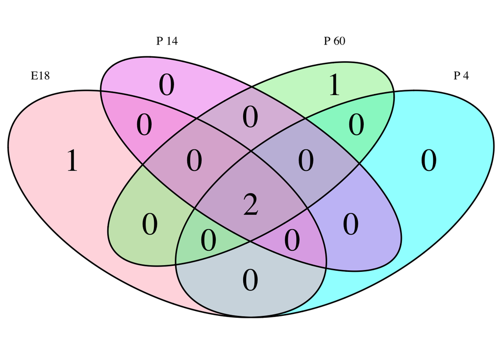

```r
# Combine the lists into a named list for the Venn diagram
venn_data <- list("E18"=dge_edgr_up_E18_sex,"P 4"=dge_edgr_up_P4_sex,"P 14"=dge_edgr_up_P14_sex,"P 60"=dge_edgr_up_P60_sex )

# Create the Venn diagram with custom colors
vennColors <- c("lightpink", "cyan1", "violet","lightgreen" )

# Set up the Venn diagram configuration
venn_config <- venn.diagram(
  x = venn_data,
  category.names = names(venn_data),
  fill = vennColors,
  filename = NULL, # Set filename to NULL to display the plot directly in R session
  imagetype = "png", # You can change this to other formats like "pdf", "jpeg", etc.
  col = "black", # Set background color to transparent for better display in R session
  cex = 2.7,
  cex.label = 7,
  lwd = 2
)

# Display the Venn diagram
grid.newpage()
grid.draw(venn_config)
```

## VennDiagram Sex wise down regulated DEGs

Overlapping genes are Uty, Kdm5d, Ddx3y and Eif2s3y.

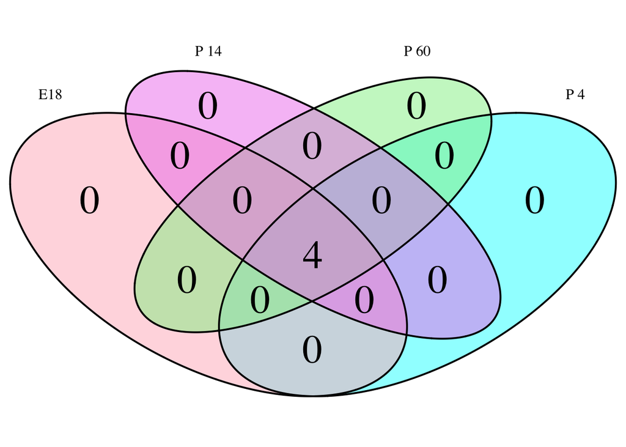

```r
library(VennDiagram)
# Combine the lists into a named list for the Venn diagram
venn_data <- list("E18"=dge_edgr_down_E18_sex,"P 4"=dge_edgr_down_P4_sex,"P 14"=dge_edgr_down_P14_sex,"P 60"=dge_edgr_down_P60_sex )

# Create the Venn diagram with custom colors
vennColors <- c("lightpink", "cyan1", "violet","lightgreen" )

# Set up the Venn diagram configuration
venn_config <- venn.diagram(
  x = venn_data,
  category.names = names(venn_data),
  fill = vennColors,
  filename = NULL, # Set filename to NULL to display the plot directly in R session
  imagetype = "png", # You can change this to other formats like "pdf", "jpeg", etc.
  col = "black", # Set background color to transparent for better display in R session
  cex = 2.7,
  cex.label = 7,
  lwd = 2
)

# Display the Venn diagram
grid.newpage()
grid.draw(venn_config)
```

## ANOVA-like testing -Age wise DEGs at various age groups

## For Female

```r
con <- makeContrasts(F18vsF4 = F.E18 - F.P4, FP4vsFP14  = F.P4 - F.P14,FP14vsFP60_S  = F.P14 - F.P60_S, levels=design)
```

```r
anov <- glmQLFTest(fit, contrast=con)
topTags(anov)
```

```
## Coefficient:  LR test on 3 degrees of freedom
##         logFC.F18vsF4 logFC.FP4vsFP14 logFC.FP14vsFP60_S   logCPM        F
## Tubb2b       3.660632       0.3569688         1.28418074 7.650877 195.4029
## Upk1b       -3.504299      -4.8391019        -2.31519038 5.001099 182.7599
## Csmd3       -1.225269      -2.1167422        -3.13064475 6.151900 151.0091
## H19          2.844524       5.0033005         3.62122986 6.629837 175.1150
## Spp1        -0.683056       5.0396853         0.47867969 7.837744 141.2100
## Syt4         5.944668       1.4301000         0.56221453 3.655665 113.1296
## Tuba1a       2.918742       0.3024229         0.03879498 9.174220 108.2481
## Bcl11a       3.889353       1.5299093         1.03870810 4.323340 106.7767
## Bcl11b       4.901164       2.8379697         1.25814289 3.556924 104.8306
## Igf2bp3     -0.137640       1.3310042         3.40016750 4.987740 104.2784
##               PValue          FDR
## Tubb2b  1.169030e-27 2.570347e-23
## Upk1b   2.596377e-26 2.854327e-22
## Csmd3   4.177366e-25 2.931019e-21
## H19     5.332276e-25 2.931019e-21
## Spp1    7.981165e-24 3.509637e-20
## Syt4    2.525714e-22 9.255481e-19
## Tuba1a  6.585321e-22 2.068449e-18
## Bcl11a  8.855439e-22 2.433807e-18
## Bcl11b  1.317398e-21 3.218403e-18
## Igf2bp3 1.476249e-21 3.245828e-18
```

```r
con <- makeContrasts(F18vsF4 = F.E18 - F.P4, levels=design)
qlf <- glmQLFTest(fit, contrast= con )
topTags(qlf)
```

```
## Coefficient:  1*F.E18 -1*F.P4
##            logFC   logCPM         F       PValue          FDR
## Tubb2b  3.660632 7.650877 141.76421 3.132993e-16 6.888512e-12
## Tuba1a  2.918742 9.174220 106.45176 5.344537e-14 5.875516e-10
## Syt4    5.944668 3.655665  95.32687 3.451929e-13 2.529919e-09
## Mllt11  2.962627 5.239822  85.12274 2.180032e-12 1.198309e-08
## Rtn1    2.489081 6.812925  83.29656 3.077237e-12 1.353184e-08
## Khdrbs3 2.248248 5.494047  81.37894 4.442372e-12 1.534461e-08
## Atat1   2.535963 4.943119  80.88717 4.885262e-12 1.534461e-08
## Mpped1  5.145844 4.526629  94.29156 6.612978e-12 1.817494e-08
## Gpc2    3.294163 5.388360  77.31937 9.843134e-12 2.404678e-08
## Peg13   1.920862 5.993750  74.38474 1.778127e-11 3.909567e-08
```

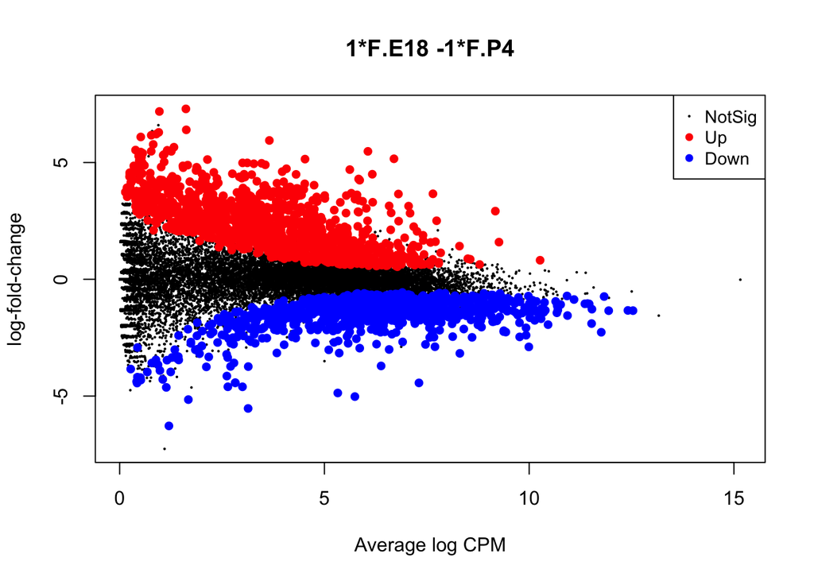

```r
plotMD(qlf)
```

```r
summary(decideTests(qlf))
```

```
##        1*F.E18 -1*F.P4
## Down               979
## NotSig           19797
## Up                1211
```

```r
table(p.adjust(qlf$table$PValue, method = "BH") < 0.05)
```

```
##
## FALSE  TRUE
## 19797  2190
```

```r
dge<-topTags(qlf, n=Inf)
dge_edgR <-dge
sig <- subset(dge_edgR$table,FDR < 0.05)
dge_edgr_up_F_18_VS_4 <-rownames(subset(sig,logFC>0.4))
dge_edgr_down_F_18_VS_4 <-rownames(subset(sig,logFC<0.4))
```

```r
con <- makeContrasts( FP4vsFP14  = F.P4 - F.P14, levels=design)
qlf <- glmQLFTest(fit, contrast= con )
topTags(qlf)
```

```
## Coefficient:  -1*F.P14 1*F.P4
##            logFC   logCPM         F       PValue          FDR
## Spp1    5.039685 7.837744 256.67070 6.704830e-21 1.474191e-16
## H19     5.003301 6.629837 141.55381 1.443798e-15 1.256029e-11
## Upk1b  -4.839102 5.001099 133.56467 1.713780e-15 1.256029e-11
## Pmp22  -2.309977 8.186159 126.50819 2.538488e-15 1.395344e-11
## Gpnmb   4.047557 4.012157 122.32389 4.652212e-15 2.045764e-11
## Slc1a4  2.632538 6.341691 115.35535 1.319654e-14 4.835872e-11
## Gpx3    3.299626 4.971314 104.65858 9.603285e-14 3.016392e-10
## Itgax   2.853578 4.717405  99.31717 1.739671e-13 4.781269e-10
## Mcm6    1.857168 5.964847  91.00138 7.415815e-13 1.811683e-09
## Rrm1    1.644265 6.264222  89.34262 1.000602e-12 2.063748e-09
```

```r
summary(decideTests(qlf))
```

```
##        -1*F.P14 1*F.P4
## Down              1036
## NotSig           19511
## Up                1440
```

```r
table(p.adjust(qlf$table$PValue, method = "BH") < 0.05)
```

```
##
## FALSE  TRUE
## 19511  2476
```

```r
dge<-topTags(qlf, n=Inf)
dge_edgR <-dge
sig <- subset(dge_edgR$table,FDR < 0.05)
dge_edgr_up_F_14VS4 <-rownames(subset(sig,logFC>0.4))
dge_edgr_down_F_14VS4 <-rownames(subset(sig,logFC<0.4))
```

```r
con <- makeContrasts(FP14vsFP60_S  = F.P14 - F.P60_S, levels=design)
qlf <- glmQLFTest(fit, contrast= con )
topTags(qlf)
```

```
## Coefficient:  1*F.P14 -1*F.P60_S
##             logFC   logCPM         F       PValue          FDR
## Csmd3   -3.130645 6.151900 184.07844 2.055346e-18 4.519090e-14
## Igf2bp3  3.400167 4.987740 162.84625 2.257327e-17 2.481592e-13
## Cry1     2.231098 5.174685 124.57113 3.354087e-15 2.262649e-11
## Upk1b   -2.315190 5.001099 127.11710 4.116340e-15 2.262649e-11
## Igfbp4   2.019214 7.279693 117.57738 9.419266e-15 4.142028e-11
## Ehd1     2.184109 6.416029 107.55270 4.476415e-14 1.640382e-10
## Lrba    -1.465684 6.940506 105.66539 6.070589e-14 1.906772e-10
## Tlr3    -1.949938 6.156860 101.56679 1.191853e-13 3.275660e-10
## Cd48    -1.953092 5.131887  94.84538 3.754308e-13 8.968126e-10
## Gcnt1   -1.737344 6.826079  94.37158 4.078831e-13 8.968126e-10
```

```r
summary(decideTests(qlf))
```

```
##        1*F.P14 -1*F.P60_S
## Down                 1358
## NotSig              18746
## Up                   1883
```

```r
table(p.adjust(qlf$table$PValue, method = "BH") < 0.05)
```

```
##
## FALSE  TRUE
## 18746  3241
```

```r
dge<-topTags(qlf, n=Inf)
dge_edgR <-dge
sig <- subset(dge_edgR$table,FDR < 0.05)
dge_edgr_up_F_14VS60 <-rownames(subset(sig,logFC>0.4))
dge_edgr_down_F_14VS60 <-rownames(subset(sig,logFC<0.4))
```

## VennDiagram Female age wise up regulated DEGs

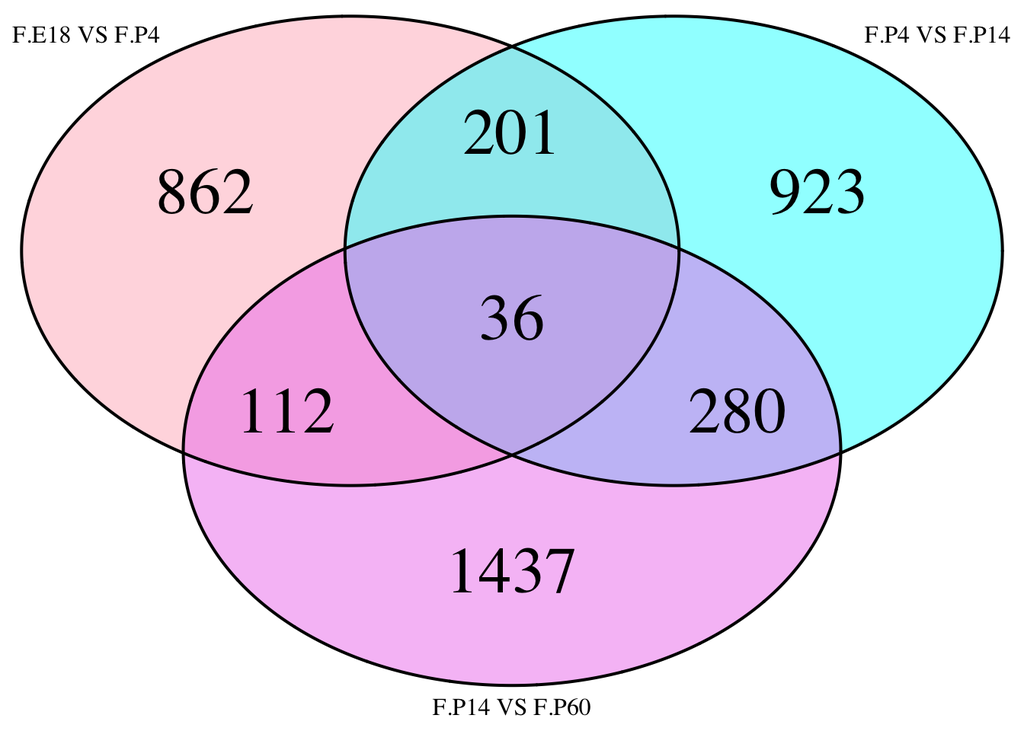

```r
# Combine the lists into a named list for the Venn diagram
venn_data <- list("F.E18 VS F.P4"=dge_edgr_up_F_18_VS_4,"F.P4 VS F.P14"=dge_edgr_up_F_14VS4,"F.P14 VS F.P60"=dge_edgr_up_F_14VS60 )

# Create the Venn diagram with custom colors
vennColors <- c("lightpink", "cyan1", "violet" )

# Set up the Venn diagram configuration
venn_config <- venn.diagram(
  x = venn_data,
  category.names = names(venn_data),
  fill = vennColors,
  filename = NULL, # Set filename to NULL to display the plot directly in R session
  imagetype = "png", # You can change this to other formats like "pdf", "jpeg", etc.
  col = "black", # Set background color to transparent for better display in R session
  cex = 2.7,
  cex.label = 7,
  lwd = 2
)

# Display the Venn diagram
grid.newpage()
grid.draw(venn_config)
```

## VennDiagram Female age wise down regulated DEGs

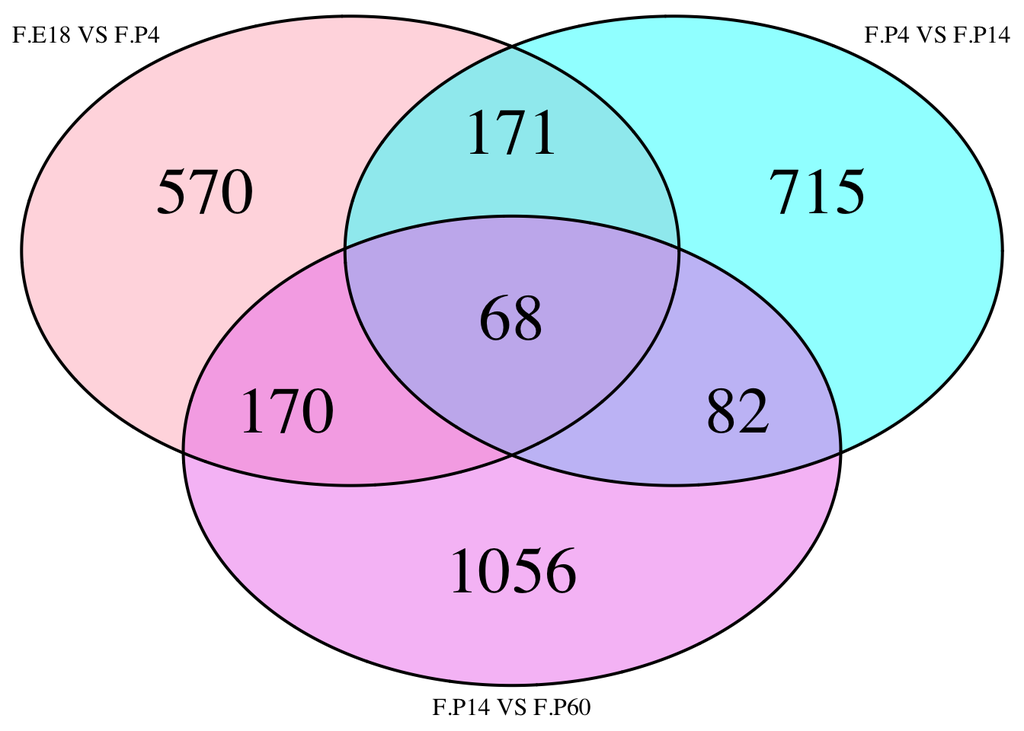

```r
# Combine the lists into a named list for the Venn diagram
venn_data <- list("F.E18 VS F.P4"=dge_edgr_down_F_18_VS_4,"F.P4 VS F.P14"=dge_edgr_down_F_14VS4,"F.P14 VS F.P60"=dge_edgr_down_F_14VS60 )

# Create the Venn diagram with custom colors
vennColors <- c("lightpink", "cyan1", "violet" )

# Set up the Venn diagram configuration
venn_config <- venn.diagram(
  x = venn_data,
  category.names = names(venn_data),
  fill = vennColors,
  filename = NULL, # Set filename to NULL to display the plot directly in R session
  imagetype = "png", # You can change this to other formats like "pdf", "jpeg", etc.
  col = "black", # Set background color to transparent for better display in R session
  cex = 2.7,
  cex.label = 7,
  lwd = 2
)

# Display the Venn diagram
grid.newpage()
grid.draw(venn_config)
```

### age wise for male

```r
con <- makeContrasts(M18vsM4 = M.E18 - M.P4, MP4vsMP14  = M.P4 - M.P14,MP14vsMP60_S  = M.P14 - M.P60_S, levels=design)
```

```r
anov <- glmQLFTest(fit, contrast=con)
topTags(anov)
```

```
## Coefficient:  LR test on 3 degrees of freedom
##         logFC.M18vsM4 logFC.MP4vsMP14 logFC.MP14vsMP60_S   logCPM         F
## Tubb2b      4.0741563      -0.0830130          1.4169739 7.650877 211.25575
## H19         3.9333499       4.7603940          1.4032172 6.629837 195.71618
## Tuba1a      3.4457469      -0.0194637          0.5153165 9.174220 155.82658
## Upk1b       0.1055828      -5.2401663         -1.8594253 5.001099 150.06003
## Csmd3      -0.4410052      -2.3225909         -2.9632839 6.151900 130.88951
## Mllt11      3.3951745       0.2350946          0.8213638 5.239822 127.58066
## Syt4        7.5680497      -0.4341591          1.6854671 3.655665 124.26880
## Spp1        0.5103498       4.3745285          1.0672523 7.837744 131.45354
## Tubb5       1.7526145       0.7582531          0.7602250 9.263142  98.97211
## Igf2bp3    -0.7106837       1.3939734          3.8100840 4.987740  98.59730
##               PValue          FDR
## Tubb2b  1.922939e-28 4.227967e-24
## H19     5.162177e-26 5.675039e-22
## Tuba1a  2.056298e-25 1.507061e-21
## Upk1b   1.950387e-24 1.072079e-20
## Csmd3   1.022446e-23 4.496103e-20
## Mllt11  1.802969e-23 6.606979e-20
## Syt4    3.223043e-23 1.012358e-19
## Spp1    3.703800e-23 1.017943e-19
## Tubb5   4.530256e-21 1.038341e-17
## Igf2bp3 4.913100e-21 1.038341e-17
```

```r
con <- makeContrasts(M18vsM4 = M.E18 - M.P4, levels=design)
qlf <- glmQLFTest(fit, contrast= con )
topTags(qlf)
```

```
## Coefficient:  1*M.E18 -1*M.P4
##             logFC   logCPM         F       PValue          FDR
## Tubb2b   4.074156 7.650877 178.72279 3.682599e-18 8.096930e-14
## Tuba1a   3.445747 9.174220 152.03192 8.405937e-17 9.241067e-13
## Syt4     7.568050 3.655665 118.01130 8.823647e-15 6.466851e-11
## Mllt11   3.395175 5.239822 114.60387 1.480596e-14 8.138468e-11
## Khdrbs3  2.430477 5.494047 100.52513 1.418944e-13 6.239664e-10
## Mpped1   5.849424 4.526629 112.78821 5.240666e-13 1.920442e-09
## Rtn1     2.473514 6.812925  88.74946 1.114723e-12 3.501346e-09
## Prune2  -2.611624 5.212978  87.23886 1.470779e-12 4.042252e-09
## Atat1    2.508943 4.943119  84.15855 2.613625e-12 6.385086e-09
## Klhdc2   1.614210 5.957402  83.31563 3.066109e-12 6.741453e-09
```

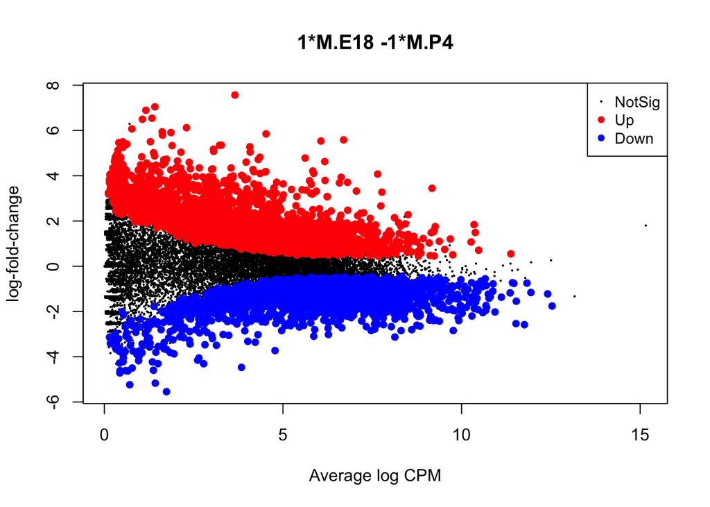

```r
plotMD(qlf)
```

```r
summary(decideTests(qlf))
```

```
##        1*M.E18 -1*M.P4
## Down              2414
## NotSig           16702
## Up                2871
```

```r
table(p.adjust(qlf$table$PValue, method = "BH") < 0.05)
```

```
##
## FALSE  TRUE
## 16702  5285
```

```r
dge<-topTags(qlf, n=Inf)
dge_edgR <-dge
sig <- subset(dge_edgR$table,FDR < 0.05)
dge_edgr_up_M_18_VS_4 <-rownames(subset(sig,logFC>0.4))
dge_edgr_down_M_18_VS_4 <-rownames(subset(sig,logFC<0.4))
```

```r
con <- makeContrasts( MP4vsMP14  = M.P4 - M.P14, levels=design)
qlf <- glmQLFTest(fit, contrast= con )
topTags(qlf)
```

```
## Coefficient:  -1*M.P14 1*M.P4
##             logFC   logCPM         F       PValue          FDR
## Spp1     4.374529 7.837744 191.89145 2.137321e-18 4.699329e-14
## Upk1b   -5.240166 5.001099 138.55406 8.885993e-16 9.768816e-12
## Pmp22   -2.194097 8.186159 115.60111 1.271058e-14 9.315584e-11
## Slc1a4   2.643356 6.341691 113.44512 1.769915e-14 9.728778e-11
## Mcm4     1.865720 5.406359 105.88121 5.861652e-14 2.577603e-10
## H19      4.760394 6.629837 100.17863 4.460995e-13 1.634731e-09
## St3gal6 -1.810821 8.014396  88.21468 1.229224e-12 3.860993e-09
## Itgal    2.355278 5.264359  85.47241 2.041899e-12 5.226233e-09
## Gpx3     3.054601 4.971314  86.52450 2.139268e-12 5.226233e-09
## Gpnmb    3.678825 4.012157  83.64546 2.880051e-12 6.284263e-09
```

```r
summary(decideTests(qlf))
```

```
##        -1*M.P14 1*M.P4
## Down              1303
## NotSig           18853
## Up                1831
```

```r
table(p.adjust(qlf$table$PValue, method = "BH") < 0.05)
```

```
##
## FALSE  TRUE
## 18853  3134
```

```r
dge<-topTags(qlf, n=Inf)
dge_edgR <-dge
sig <- subset(dge_edgR$table,FDR < 0.05)
dge_edgr_up_M_14VS4 <-rownames(subset(sig,logFC>0.4))
dge_edgr_down_M_14VS4 <-rownames(subset(sig,logFC<0.4))
```

```r
con <- makeContrasts(MP14vsMP60_S  = M.P14 - M.P60_S, levels=design)
qlf <- glmQLFTest(fit, contrast= con )
topTags(qlf)
```

```
## Coefficient:  1*M.P14 -1*M.P60_S
##                   logFC   logCPM         F       PValue          FDR
## Igf2bp3        3.810084 4.987740 171.54324 8.226222e-18 1.808699e-13
## Csmd3         -2.963284 6.151900 144.91721 2.076282e-16 2.282560e-12
## Lrba          -1.596163 6.940506 107.63963 4.414433e-14 3.235338e-10
## Igfbp4         1.956025 7.279693  90.51502 8.093640e-13 4.448872e-09
## 2210403K04Rik  2.602919 5.891316  84.79221 2.319555e-12 9.558023e-09
## Map2k3         2.349790 7.449069  84.16940 2.608275e-12 9.558023e-09
## Prc1           2.933957 5.450796  82.54021 3.554455e-12 1.092947e-08
## Lpl            2.857147 8.055035  82.24282 3.976703e-12 1.092947e-08
## Mmp19          1.948433 5.398075  79.64952 6.215309e-12 1.518400e-08
## Cry1           1.860399 5.174685  77.47300 9.546726e-12 2.099039e-08
```

```r
summary(decideTests(qlf))
```

```
##        1*M.P14 -1*M.P60_S
## Down                 1731
## NotSig              18433
## Up                   1823
```

```r
table(p.adjust(qlf$table$PValue, method = "BH") < 0.05)
```

```
##
## FALSE  TRUE
## 18433  3554
```

```r
dge<-topTags(qlf, n=Inf)
dge_edgR <-dge
sig <- subset(dge_edgR$table,FDR < 0.05)
dge_edgr_up_M_14VS60 <-rownames(subset(sig,logFC>0.4))
dge_edgr_down_M_14VS60 <-rownames(subset(sig,logFC<0.4))
```

### VennDiagram Male age wise up regulated DEGs

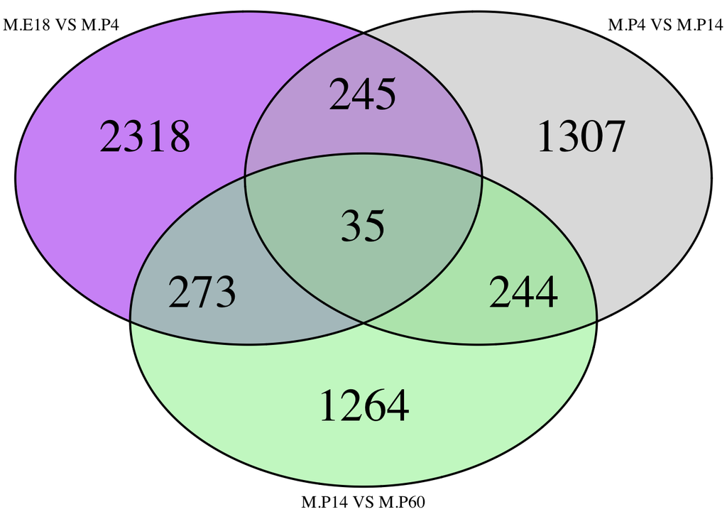

```r
# Combine the lists into a named list for the Venn diagram
venn_data <- list("M.E18 VS M.P4"=dge_edgr_up_M_18_VS_4,"M.P4 VS M.P14"=dge_edgr_up_M_14VS4,"M.P14 VS M.P60"=dge_edgr_up_M_14VS60 )

# Create the Venn diagram with custom colors
vennColors <- c("purple", "grey", "lightgreen" )

# Set up the Venn diagram configuration
venn_config <- venn.diagram(
  x = venn_data,
  category.names = names(venn_data),
  fill = vennColors,
  filename = NULL, # Set filename to NULL to display the plot directly in R session
  imagetype = "png", # You can change this to other formats like "pdf", "jpeg", etc.
  col = "black", # Set background color to transparent for better display in R session
  cex = 2.7,
  cex.label = 7,
  lwd = 2
)

# Display the Venn diagram
grid.newpage()
grid.draw(venn_config)
```

### VennDiagram Male age wise down regulated DEGs

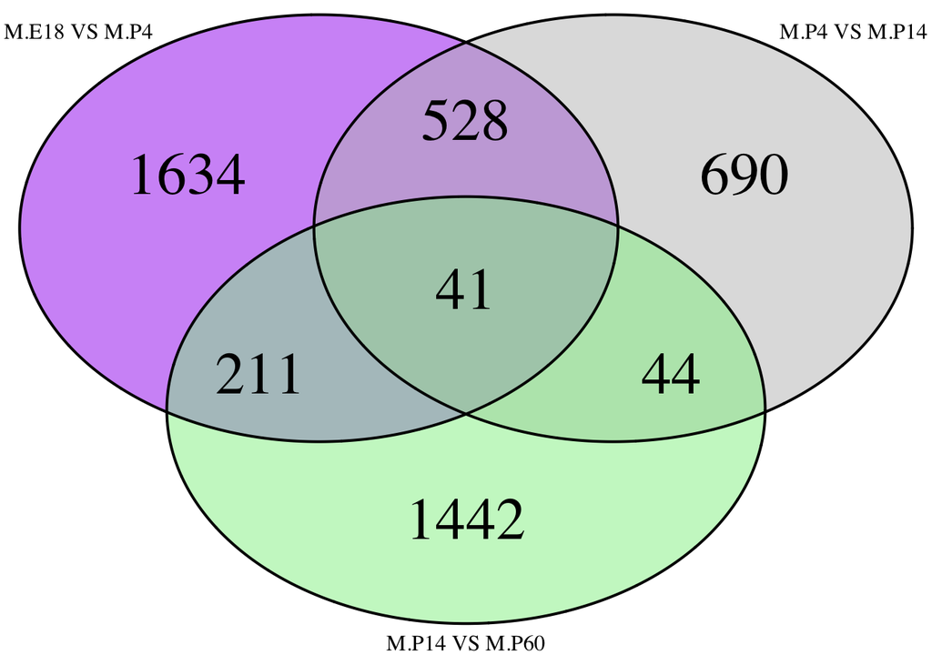

```r
# Combine the lists into a named list for the Venn diagram
venn_data <- list("M.E18 VS M.P4"=dge_edgr_down_M_18_VS_4,"M.P4 VS M.P14"=dge_edgr_down_M_14VS4,"M.P14 VS M.P60"=dge_edgr_down_M_14VS60 )

# Create the Venn diagram with custom colors
vennColors <- c("purple", "grey", "lightgreen" )

# Set up the Venn diagram configuration
venn_config <- venn.diagram(
  x = venn_data,
  category.names = names(venn_data),
  fill = vennColors,
  filename = NULL, # Set filename to NULL to display the plot directly in R session
  imagetype = "png", # You can change this to other formats like "pdf", "jpeg", etc.
  col = "black", # Set background color to transparent for better display in R session
  cex = 2.7,
  cex.label = 7,
  lwd = 2
)

# Display the Venn diagram
grid.newpage()
grid.draw(venn_config)
```

```r
getwd()
```

```
## [1] "/Users/nishapaudel/Documents/CASP"
```